# Linear Regression from Scracth

An implementation using only numpy

Debaditya Chakraborty

2025-12-02

# To begin

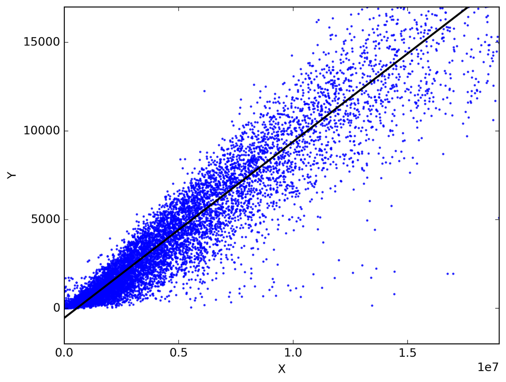

Linear regression is possibly the most commonly used statistical and machine learning algorithm. There are plenty of resources that explain the algorithm in detail. While these explanations are valuable, a common issue arises: most people rely on pre-built libraries to implement linear regression, which has several drawbacks.

First, using a pre-built function creates a gap between theoretical understanding and practical implementation. Without coding it from scratch, one might not fully grasp the underlying mathematics, such as the derivation of the cost function, gradient descent, or the normal equation. Additionally, implementing the algorithm manually allows for deeper insights into optimization techniques, numerical stability, and potential modifications for specific use cases.

[figure not shown]

In this project, I aim to build a linear regression model from scratch in python using only numpy, exploring its core concepts and implementation step by step.

## Imports

we have only the help of our old trustworthy numpy here. Matplotlib has been used for some of the visuals, and sklearn is used to do a comparison between the used algorithm and the preexisting algorithm.

```python
import numpy as np
import matplotlib.pyplot as plt
from sklearn.linear_model import LinearRegression as SklearnLR
from sklearn.metrics import mean_squared_error
```

## Outline

The linear regression model is a special case of the [Gauss-Markov linear model](https://en.wikipedia.org/wiki/Gauss%E2%80%93Markov_theorem) where the [design matrix](https://en.wikipedia.org/wiki/Design_matrix) $X$ is full column rank and the response vector $\tilde{y}$ contains continuous values. We write the Gauss-Markov linear model as:

$$y = X\beta + \epsilon$$

where $\mathbb{E}(\epsilon) = 0$, and $\text{Var}(\epsilon) = \sigma^2 I$, with $I$ being the identity matrix. $\text{Var}(\epsilon)$ is the [dispersion matrix](https://en.wikipedia.org/wiki/Covariance_matrix) of the errors in the model.

Here we know $y$ and $X$, and from the model-building process, we assume the errors are iid with mean 0 and constant variance $\sigma^2$. The only unknown is the vector $\beta$, which contains the parameters of the model. How do we find it?

This is fundamentally an **estimation problem**. We want estimates of $\beta$ that are as close as possible to their true values. Since we assume our response is a linear combination of the columns of $X$ plus some noise, we want to find the coefficients $\beta$ that give the **best linear combination**.

But what does “best” mean? In statistics, “best” often refers to estimators that are **unbiased** and have **minimum variance**. In the context of linear regression, this leads to the **Least Squares Estimate**, which under our assumptions has a closed-form solution. The estimate is given by:

$$\hat{\beta}_{LS} = (X'X)^{-1}X'y$$

### Where does this come from?

[figure not shown]

We start from the model:

$$y = X\beta + \epsilon$$

Assuming $X$ is full rank and the errors $\epsilon \sim \text{iid}(0, \sigma^2)$, we define the **residuals** as $y - X\beta$, the difference between the observed and predicted values. We now define the **objective**: minimize the **sum of squared residuals**:

$$\min_{\beta} (y - X\beta)'(y - X\beta)$$

Expanding the expression:

$$= y'y - 2\beta'X'y + \beta'X'X\beta$$

Taking the derivative with respect to $\beta$ and setting it to zero:

$$-2X'y + 2X'X\beta = 0 \Rightarrow X'X\beta = X'y$$

Since $X'X$ is invertible(As $X$ was Full rank), we get:

$$\hat{\beta} = (X'X)^{-1}X'y$$

This is the **least squares solution** — the best linear unbiased estimator (BLUE) under the Gauss-Markov assumptions.

### The Machine Learning Perspective: Gradient Descent

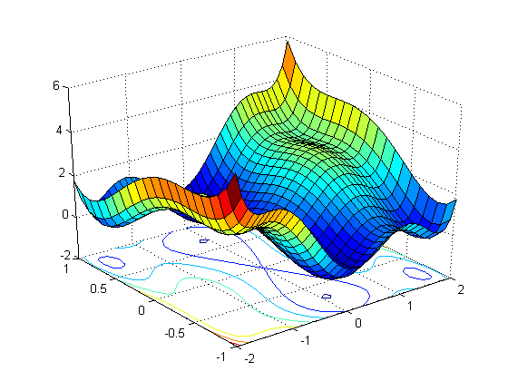

That was the classical statistical approach. But in practice, especially with large or messy data, computing matrix inverses can be computationally expensive or even impossible (e.g., when $X'X$ is singular or ill-conditioned).

Computer scientists approached the same estimation problem differently: instead of computing an exact closed-form solution, they proposed **iterative optimization algorithms** like **Gradient Descent** to find the parameters $\beta$ that minimize the same squared error objective.

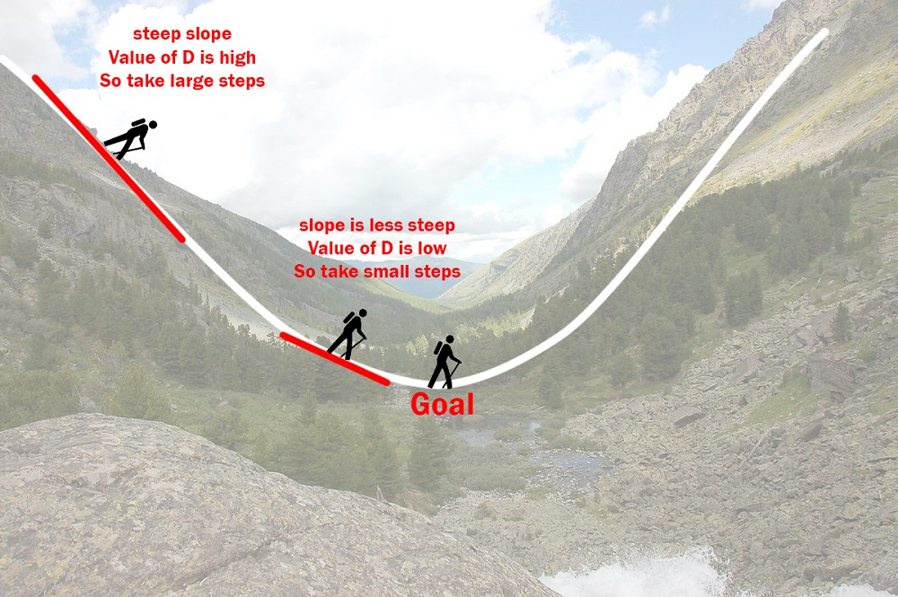

As the name suggests the algorithm finds the gradients along the surface and then chooses the steepest descent and keeps going until it reaches a local minima, Seldom loss functions don’t look like such a nice shape with a unique global minima, but as long as the local minimas are close to each other we are okay to reach at any one of them.

Gradient Descent doesn’t rely on matrix inversion. It starts with an initial guess for $\beta$, then repeatedly updates it in the direction that most rapidly reduces the error. This is done by moving in the direction **opposite to the gradient** of the cost function.

The update rule is:

$$\beta := \beta - \alpha \nabla J(\beta)$$

Where:

- $\alpha$ is the learning rate (step size),
- $J(\beta)$ is the cost function $\frac{1}{2m} \sum (y - X\beta)^2$,
- $\nabla J(\beta) = -X'(y - X\beta)$ is the gradient.

With careful choice of the learning rate and enough iterations, this method converges to the same solution (or close to it), even when the assumptions of the Gauss-Markov model are violated.

But there are times when gradient descent can not reach close to solutions, can you guess when ?

Now, Lets begin with the code,

## The Code

```python
class LinearRegression:
    def __init__(self):
        self.theta = None
        self.mean = None
        self.std = None

    def feature_scaling(self, X):
        self.mean = np.mean(X, axis=0)
        self.std = np.std(X, axis=0)
        return (X - self.mean) / self.std

    def fit_normal_eq(self, X, y):
        X_b = np.c_[np.ones((X.shape[0], 1)), X]  # Add bias term (intercept)
        self.theta = np.linalg.pinv(X_b) @ y  # Use pseudo-inverse for robustness
        return self.theta

    def fit_gradient_descent(self, X, y, alpha=0.1, iterations=1000):
        X_scaled = self.feature_scaling(X)
        m, n = X_scaled.shape
        X_b = np.c_[np.ones((m, 1)), X_scaled]  # Add bias term
        self.theta = np.zeros((n + 1, 1))  # Initialize parameters
        cost_history = []

        for i in range(iterations):
            gradients = (1/m) * X_b.T @ (X_b @ self.theta - y)
            self.theta -= alpha * gradients
            cost = (1/(2*m)) * np.sum((X_b @ self.theta - y)**2)
            cost_history.append(cost)

        return self.theta, cost_history

    def compare_models(self, X, y):
        # Normal Equation
        theta_normal_eq = self.fit_normal_eq(X, y)

        # Gradient Descent
        # Gradient Descent
        theta_gd_scaled, cost_history = self.fit_gradient_descent(X, y)

        # Rescale gradient descent coefficients
        theta_gd = np.zeros_like(theta_gd_scaled)
        theta_gd[1:] = theta_gd_scaled[1:] / self.std.reshape(-1, 1)
        theta_gd[0] = theta_gd_scaled[0] - np.sum((theta_gd_scaled[1:].flatten() * self.mean) / self.std).reshape(-1, 1)

        # Scikit-Learn Model
        model = SklearnLR()
        model.fit(X, y)
        theta_sklearn = np.vstack((model.intercept_, model.coef_.reshape(-1,1)))

        # Print results
        print("Normal Equation Coefficients:\n", theta_normal_eq[:5])  # Print first few coeffs
        print("Gradient Descent Coefficients:\n", theta_gd[:5])
        print("Scikit-Learn Coefficients:\n", theta_sklearn[:5])

        # Plot cost function over iterations
        plt.plot(cost_history)
        plt.xlabel("Iterations")
        plt.ylabel("Cost Function (MSE)")
        plt.title("Gradient Descent Convergence")
        plt.show()

        # Compute errors
        mse_normal_eq = mean_squared_error(y, np.c_[np.ones((X.shape[0], 1)), X] @ theta_normal_eq)
        mse_gd = mean_squared_error(y, np.c_[np.ones((X.shape[0], 1)), X ] @ theta_gd)
        mse_sklearn = mean_squared_error(y, model.predict(X))

        print(f"MSE (Normal Equation): {mse_normal_eq:.5f}")
        print(f"MSE (Gradient Descent): {mse_gd:.5f}")
        print(f"MSE (Scikit-Learn): {mse_sklearn:.5f}")
```

The whole code has been wrapped inside the class `LinearRegression` which contains several objects , lets break apart the different sections of the code.

```python
class LinearRegression:
    def __init__(self):
        self.theta = None
        self.mean = None
        self.std = None
```

Here we are initializing our class Called Linear Regression with the object values theta , mean and std as set to None. These are the essential object values that we’ll be using in different sections of the class.

```python
    def feature_scaling(self, X):
        self.mean = np.mean(X, axis=0)
        self.std = np.std(X, axis=0)
        return (X - self.mean) / self.std
```

Here we are defining the feature scaling function, This function is akin to a standardized scaler method. It Transforms our explanatory variables/features to a scale with 0 mean.

```python
    def fit_normal_eq(self, X, y):
        X_b = np.c_[np.ones((X.shape[0], 1)), X]
        self.theta = np.linalg.pinv(X_b) @ y  # Use pseudo-inverse for robustness
        return self.theta
```

This function takes in the design matrix and the target/resposnse variables as input and calculates the Beta(Which in the code is theta, i forgot to change it to beta) vector explicitly using the normal equations form the formula that we found earlier. Note that it adds a Column of 1s to the design matrix, this is to add for the intercept term in the regression model, this is not a necessity if the whole data including the target variable was scaled, but since we did not scale the target variable we need to add for the bias. In the next line we are using `linalg.pinv()` function from numpy to calculate the moore-penrose generalized inverse of the matrix X, this is a more general solution as compared to the standard inverse of a matrix, The moore penrose g inverse is unique and robust so it makes sure that our code doesn’t give error outputs for small perturbations from the standard assumptions. You can read more about Generalized Inverses [here](https://home.iitk.ac.in/~rksr/html/08Ginv.htm) . Note that this looks a bit different than what we had found earlier but this is not different, the general solution for any gauss markov linear model uses the Generalied inverse $(X'X)^-$ ,instead of the usual inverse which doesn’t exist in many cases.

```python
 def fit_gradient_descent(self, X, y, alpha=0.1, iterations=1000):
        X_scaled = self.feature_scaling(X)
        m, n = X_scaled.shape
        X_b = np.c_[np.ones((m, 1)), X_scaled]  # Add bias term
        self.theta = np.zeros((n + 1, 1))  # Initialize parameters
        cost_history = []

        for i in range(iterations):
            gradients = (1/m) * X_b.T @ (X_b @ self.theta - y)
            self.theta -= alpha * gradients
            cost = (1/(2*m)) * np.sum((X_b @ self.theta - y)**2)
            cost_history.append(cost)

        return self.theta, cost_history
```

This is the gradient descent function, as we can see it takes in the Features/ Design Matrix , The Target/Response Variable , A learning rate parameter and number of epochs/iterations.

We have preassigned the learning rate and the epochs, one can easily modify these as per their choice. We want the learning rate to be small but not too small, and the epochs to be high but moderate enough so that it doesn’t require too much of computing time. The Learning rate essentialy tells us how big of the steps we want to take, taking larger steps would mean going towards the minima faster, but also there’s a chance that we may miss the minima. Similarly the number of epochs is how many times we should run the algorithm. We have initially setup the required data, and have also created a cost history array which gives us how fast we reached convergence, note that we have initialized a set of parameters as the intial value and this is set as zero, we can choose random values or if there’s some pre existing knowledge more precise values can be chosen for faster convergence. The loop part is essentially looping through the loss function via choosing parameters that offer the steepest descent, and this keeps running as long as the iterations are done. Note that gradient descent does not gurantee that it will reach a global or even a local minima as the closer you go to the minima the smaller the gradients will be, so it will be close to the minimum value. You can learn more about gradient descent and specifically it’s application to regression [here](https://introml.mit.edu/notes/gradient_descent.html#sec-gd_ridge)

```python
    def compare_models(self, X, y):
        # Normal Equation
        theta_normal_eq = self.fit_normal_eq(X, y)

        # Gradient Descent (trained on standardized X)
        theta_s, cost_history = self.fit_gradient_descent(X, y)

        # Unscale coefficients to original feature space
        b = theta_s[1:].ravel()            # coefficients for scaled features
        w = b / self.std                   # convert slopes back
        w0 = float(theta_s[0]) - np.sum(b * self.mean / self.std)

        theta_gd = np.r_[w0, w].reshape(-1, 1)

        # Scikit-Learn Model
        model = SklearnLR()
        model.fit(X, y)
        theta_sklearn = np.vstack((model.intercept_, model.coef_.reshape(-1,1)))

        # Print results
        print("Normal Equation Coefficients:\n", theta_normal_eq[:5])  # Print first few coeffs
        print("Gradient Descent Coefficients:\n", theta_gd[:5])
        print("Scikit-Learn Coefficients:\n", theta_sklearn[:5])

        # Plot cost function over iterations
        plt.plot(cost_history)
        plt.xlabel("Iterations")
        plt.ylabel("Cost Function (MSE)")
        plt.title("Gradient Descent Convergence")
        plt.show()

        # Compute errors
        mse_normal_eq = mean_squared_error(y, np.c_[np.ones((X.shape[0], 1)), X] @ theta_normal_eq)
        mse_gd = mean_squared_error(y, np.c_[np.ones((X.shape[0], 1)), self.feature_scaling(X)] @ theta_gd)
        mse_sklearn = mean_squared_error(y, model.predict(X))

        print(f"MSE (Normal Equation): {mse_normal_eq:.5f}")
        print(f"MSE (Gradient Descent): {mse_gd:.5f}")
        print(f"MSE (Scikit-Learn): {mse_sklearn:.5f}")
```

In this final section we define a function that compares between the different models i.e the Gradient Descent Based method, the normal equation based method and the prebuilt regression method in scikit learn.The function does this by plotting the convergence of the gradient descent function and returning the MSE for the model.

Finally it’s time for the test, We first use a synthetic data that follows the assumptions that we need to test the model and see the results.

We generated a data with 100 samples, and 3 features, We have pre assigned the regression coefficients and if our model is working we should get results that are close to the actual coefficients.

```python
# Create synthetic data
np.random.seed(42)
m, n = 100, 3  # 100 samples, 3 features
X = np.random.randn(m, n)  # features
true_theta = np.array([[4], [2], [-3]])  # true weights (without intercept)
bias = 5  # intercept
y = X @ true_theta + bias + np.random.randn(m, 1)  # add noise

# Run the model
model = LinearRegression()
model.compare_models(X, y)
```

```
## Normal Equation Coefficients:
##  [[ 5.11286229]
##  [ 3.92233671]
##  [ 1.95003645]
##  [-3.10759331]]
## Gradient Descent Coefficients:
##  [[ 5.11286229]
##  [ 3.92233671]
##  [ 1.95003645]
##  [-3.10759331]]
## Scikit-Learn Coefficients:
##  [[ 5.11286229]
##  [ 3.92233671]
##  [ 1.95003645]
##  [-3.10759331]]
## MSE (Normal Equation): 0.75676
## MSE (Gradient Descent): 0.75676
## MSE (Scikit-Learn): 0.75676
```

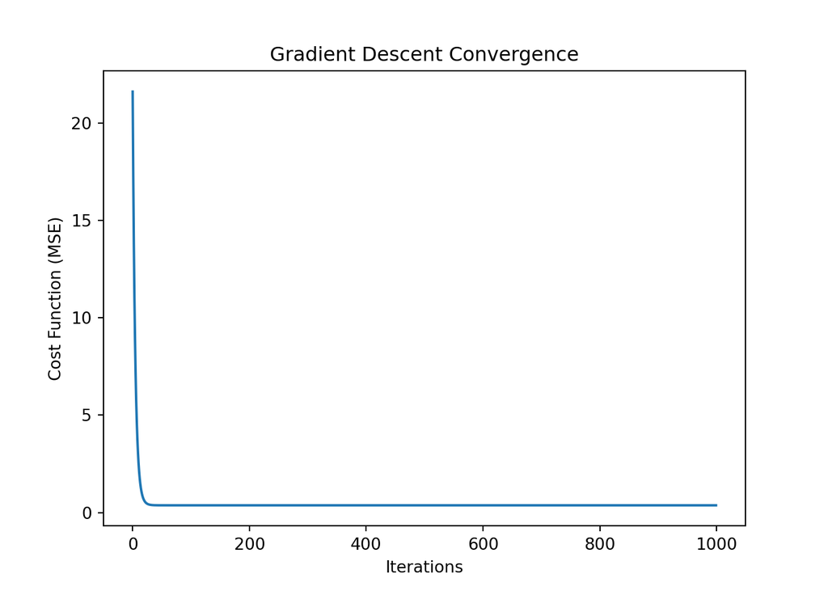

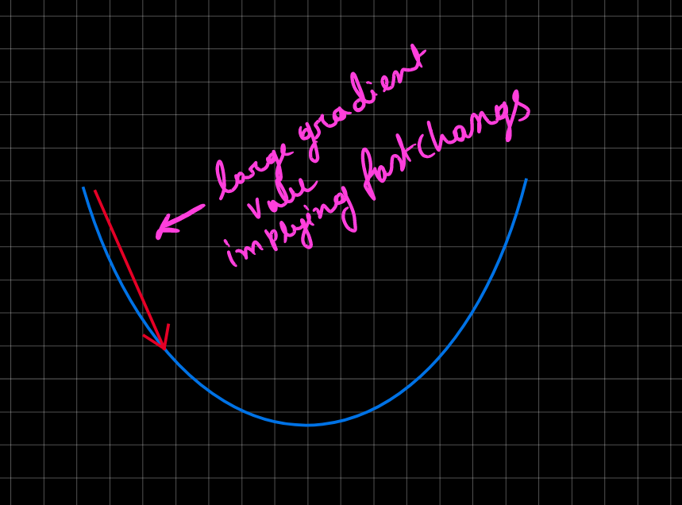

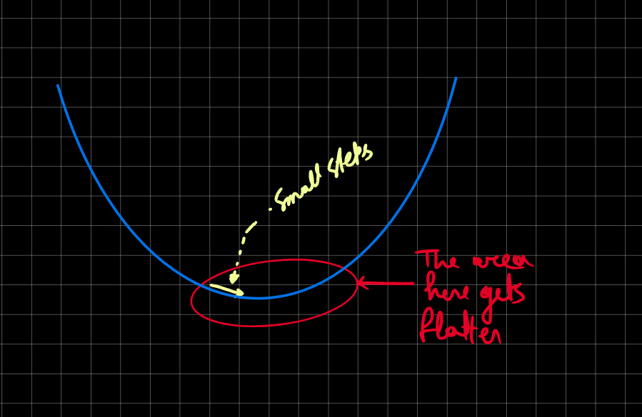

As we can see, all three approaches produce nearly identical coefficients and equal MSE values. This is expected: Scikit-Learn’s LinearRegression uses the Ordinary Least Squares (OLS) method internally, which is mathematically equivalent to the Normal Equation solution. Therefore, both yield the same optimal coefficients that minimize the sum of squared residuals.

The Gradient Descent-based approach also converges to the same solution because the cost function in linear regression is convex — it has a single global minimum. Hence, given appropriate learning rate and convergence criteria, Gradient Descent will reach the same set of parameters as the OLS-based methods.

However, in practice, Gradient Descent may stop slightly short of the true minimum if the learning rate or stopping tolerance is not tuned carefully. In such cases, the coefficients might differ slightly, even though the resulting MSE remains almost identical. This reflects the flatness of the loss surface near the minimum — small parameter changes around the optimum produce negligible differences in the RSS.

Therefore, while all three methods can provide similar predictive performance, their computational characteristics differ:

Gradient Descent: Iterative and scalable, especially for large datasets.

Scikit-Learn: A convenient wrapper implementing the OLS solution efficiently.

We can test this on the Standard California Housing Dataset ,We load the data from `sklearn.datasets`

```python
from sklearn.datasets import fetch_california_housing
# Load California Housing data
california = fetch_california_housing()
X, y = california.data, california.target.reshape(-1, 1)
```

Finally we run this using our Class

```python
# Create an instance of your class and run comparison
model = LinearRegression()
model.compare_models(X, y)
```

```
## Normal Equation Coefficients:
##  [[-3.69419202e+01]
##  [ 4.36693293e-01]
##  [ 9.43577803e-03]
##  [-1.07322041e-01]
##  [ 6.45065694e-01]]
## Gradient Descent Coefficients:
##  [[-3.68198287e+01]
##  [ 4.37340684e-01]
##  [ 9.45688983e-03]
##  [-1.08234712e-01]
##  [ 6.48944871e-01]]
## Scikit-Learn Coefficients:
##  [[-3.69419202e+01]
##  [ 4.36693293e-01]
##  [ 9.43577803e-03]
##  [-1.07322041e-01]
##  [ 6.45065694e-01]]
## MSE (Normal Equation): 0.52432
## MSE (Gradient Descent): 0.52432
## MSE (Scikit-Learn): 0.52432
```

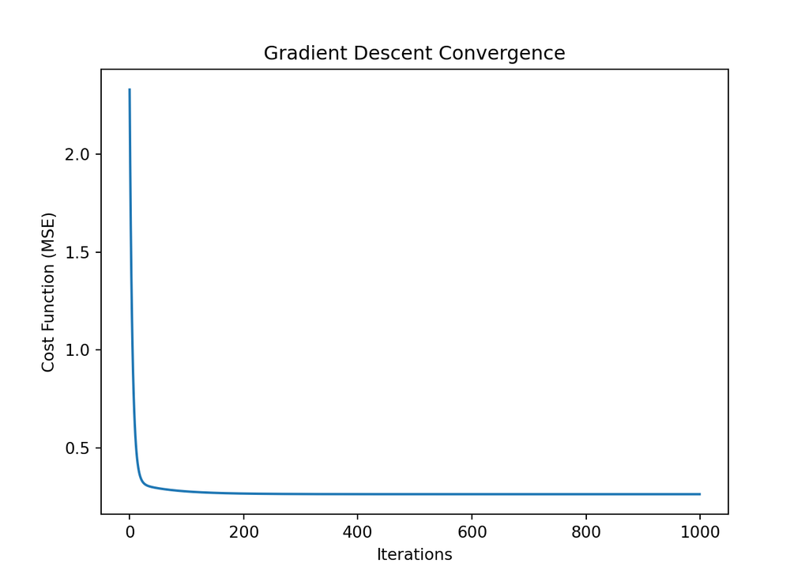

As we can see the results are similiar as compared to the Synthetic data result. The Convergence has been fast here also, maybe tuning the learning rate can give better results for the gradient descent.

So this was the whole of it, A very basic idea on how one can easily implement linear regression in python and some mathematical aspects of the problem. There are plenty of resources to look into to know the analysis and the prediction method for this problem my goal was to dive a bit into the theoretical and mathematical aspects of the same.If you have any questions do reach out to me (>__<)